# Example Titanic

```python
# 타이타닉 생존자 데이터셋
import seaborn as sns
import pandas as pd

titanic = sns.load_dataset('titanic')
```

```python
# 타이타닉 데이터셋 확인
titanic
```

|  | survived | pclass | sex | age | sibsp | parch | fare | embarked | class | who | adult_male | deck | embark_town | alive | alone |
| --- | --- | --- | --- | --- | --- | --- | --- | --- | --- | --- | --- | --- | --- | --- | --- |
| 0 | 0 | 3 | male | 22.0 | 1 | 0 | 7.2500 | S | Third | man | True | NaN | Southampton | no | False |
| 1 | 1 | 1 | female | 38.0 | 1 | 0 | 71.2833 | C | First | woman | False | C | Cherbourg | yes | False |
| 2 | 1 | 3 | female | 26.0 | 0 | 0 | 7.9250 | S | Third | woman | False | NaN | Southampton | yes | True |
| 3 | 1 | 1 | female | 35.0 | 1 | 0 | 53.1000 | S | First | woman | False | C | Southampton | yes | False |
| 4 | 0 | 3 | male | 35.0 | 0 | 0 | 8.0500 | S | Third | man | True | NaN | Southampton | no | True |
| ... | ... | ... | ... | ... | ... | ... | ... | ... | ... | ... | ... | ... | ... | ... | ... |
| 886 | 0 | 2 | male | 27.0 | 0 | 0 | 13.0000 | S | Second | man | True | NaN | Southampton | no | True |
| 887 | 1 | 1 | female | 19.0 | 0 | 0 | 30.0000 | S | First | woman | False | B | Southampton | yes | True |
| 888 | 0 | 3 | female | NaN | 1 | 2 | 23.4500 | S | Third | woman | False | NaN | Southampton | no | False |
| 889 | 1 | 1 | male | 26.0 | 0 | 0 | 30.0000 | C | First | man | True | C | Cherbourg | yes | True |
| 890 | 0 | 3 | male | 32.0 | 0 | 0 | 7.7500 | Q | Third | man | True | NaN | Queenstown | no | True |

891 rows × 15 columns

```python
# 데이터의 기초 기술 통계 확인
titanic.describe()
```

|  | survived | pclass | age | sibsp | parch | fare |
| --- | --- | --- | --- | --- | --- | --- |
| count | 891.000000 | 891.000000 | 714.000000 | 891.000000 | 891.000000 | 891.000000 |
| mean | 0.383838 | 2.308642 | 29.699118 | 0.523008 | 0.381594 | 32.204208 |
| std | 0.486592 | 0.836071 | 14.526497 | 1.102743 | 0.806057 | 49.693429 |
| min | 0.000000 | 1.000000 | 0.420000 | 0.000000 | 0.000000 | 0.000000 |
| 25% | 0.000000 | 2.000000 | 20.125000 | 0.000000 | 0.000000 | 7.910400 |
| 50% | 0.000000 | 3.000000 | 28.000000 | 0.000000 | 0.000000 | 14.454200 |
| 75% | 1.000000 | 3.000000 | 38.000000 | 1.000000 | 0.000000 | 31.000000 |
| max | 1.000000 | 3.000000 | 80.000000 | 8.000000 | 6.000000 | 512.329200 |

```python
# 결측값 확인
missing_values = titanic.isnull().sum()
missing_values
```

```
survived         0
pclass           0
sex              0
age            177
sibsp            0
parch            0
fare             0
embarked         2
class            0
who              0
adult_male       0
deck           688
embark_town      2
alive            0
alone            0
dtype: int64
```

```python
# age의 nan 값을 중간값으로 설정하기위해 중간값 계산
median_age = titanic['age'].median(axis=0)
median_age
```

```
28.0
```

```python
# age 열의 NaN값을 다른 나이 데이터의 중간값으로 변경하기
titanic['age'].fillna(median_age, inplace=True)
titanic
```

|  | survived | pclass | sex | age | sibsp | parch | fare | embarked | class | who | adult_male | deck | embark_town | alive | alone |
| --- | --- | --- | --- | --- | --- | --- | --- | --- | --- | --- | --- | --- | --- | --- | --- |
| 0 | 0 | 3 | male | 22.0 | 1 | 0 | 7.2500 | S | Third | man | True | NaN | Southampton | no | False |
| 1 | 1 | 1 | female | 38.0 | 1 | 0 | 71.2833 | C | First | woman | False | C | Cherbourg | yes | False |
| 2 | 1 | 3 | female | 26.0 | 0 | 0 | 7.9250 | S | Third | woman | False | NaN | Southampton | yes | True |
| 3 | 1 | 1 | female | 35.0 | 1 | 0 | 53.1000 | S | First | woman | False | C | Southampton | yes | False |
| 4 | 0 | 3 | male | 35.0 | 0 | 0 | 8.0500 | S | Third | man | True | NaN | Southampton | no | True |
| ... | ... | ... | ... | ... | ... | ... | ... | ... | ... | ... | ... | ... | ... | ... | ... |
| 886 | 0 | 2 | male | 27.0 | 0 | 0 | 13.0000 | S | Second | man | True | NaN | Southampton | no | True |
| 887 | 1 | 1 | female | 19.0 | 0 | 0 | 30.0000 | S | First | woman | False | B | Southampton | yes | True |
| 888 | 0 | 3 | female | 28.0 | 1 | 2 | 23.4500 | S | Third | woman | False | NaN | Southampton | no | False |
| 889 | 1 | 1 | male | 26.0 | 0 | 0 | 30.0000 | C | First | man | True | C | Cherbourg | yes | True |
| 890 | 0 | 3 | male | 32.0 | 0 | 0 | 7.7500 | Q | Third | man | True | NaN | Queenstown | no | True |

891 rows × 15 columns

```python
# 결측값 확인
missing_values = titanic.isnull().sum()
missing_values
```

```
survived         0
pclass           0
sex              0
age              0
sibsp            0
parch            0
fare             0
embarked         2
class            0
who              0
adult_male       0
deck           688
embark_town      2
alive            0
alone            0
dtype: int64
```

```python
# embark_town 열의 승선도시 중에서 가장 많이 출현한 값 확인
most_freq = titanic['embark_town'].value_counts(dropna=True).idxmax()
most_freq
```

```
'Southampton'
```

```python
# 가장 많이 출현한 값으로 embarked 열의 NaN값을 치환
titanic['embarked'].fillna(most_freq, inplace=True)
titanic
```

|  | survived | pclass | sex | age | sibsp | parch | fare | embarked | class | who | adult_male | deck | embark_town | alive | alone |
| --- | --- | --- | --- | --- | --- | --- | --- | --- | --- | --- | --- | --- | --- | --- | --- |
| 0 | 0 | 3 | male | 22.0 | 1 | 0 | 7.2500 | S | Third | man | True | NaN | Southampton | no | False |
| 1 | 1 | 1 | female | 38.0 | 1 | 0 | 71.2833 | C | First | woman | False | C | Cherbourg | yes | False |
| 2 | 1 | 3 | female | 26.0 | 0 | 0 | 7.9250 | S | Third | woman | False | NaN | Southampton | yes | True |
| 3 | 1 | 1 | female | 35.0 | 1 | 0 | 53.1000 | S | First | woman | False | C | Southampton | yes | False |
| 4 | 0 | 3 | male | 35.0 | 0 | 0 | 8.0500 | S | Third | man | True | NaN | Southampton | no | True |
| ... | ... | ... | ... | ... | ... | ... | ... | ... | ... | ... | ... | ... | ... | ... | ... |
| 886 | 0 | 2 | male | 27.0 | 0 | 0 | 13.0000 | S | Second | man | True | NaN | Southampton | no | True |
| 887 | 1 | 1 | female | 19.0 | 0 | 0 | 30.0000 | S | First | woman | False | B | Southampton | yes | True |
| 888 | 0 | 3 | female | 28.0 | 1 | 2 | 23.4500 | S | Third | woman | False | NaN | Southampton | no | False |
| 889 | 1 | 1 | male | 26.0 | 0 | 0 | 30.0000 | C | First | man | True | C | Cherbourg | yes | True |
| 890 | 0 | 3 | male | 32.0 | 0 | 0 | 7.7500 | Q | Third | man | True | NaN | Queenstown | no | True |

891 rows × 15 columns

```python
# 결측값 확인
missing_values = titanic.isnull().sum()
missing_values
```

```
survived         0
pclass           0
sex              0
age              0
sibsp            0
parch            0
fare             0
embarked         0
class            0
who              0
adult_male       0
deck           688
embark_town      2
alive            0
alone            0
dtype: int64
```

```python
# embarked 열의 승선도시 중에서 가장 많이 출현한 값 확인
most_freq = titanic['embarked'].value_counts(dropna=True).idxmax()
most_freq
```

```
'S'
```

```python
# 가장 많이 출현한 값으로 embarked 열의 NaN값을 치환
titanic['embarked'].fillna(most_freq, inplace=True)
titanic
```

|  | survived | pclass | sex | age | sibsp | parch | fare | embarked | class | who | adult_male | deck | embark_town | alive | alone |
| --- | --- | --- | --- | --- | --- | --- | --- | --- | --- | --- | --- | --- | --- | --- | --- |
| 0 | 0 | 3 | male | 22.0 | 1 | 0 | 7.2500 | S | Third | man | True | NaN | Southampton | no | False |
| 1 | 1 | 1 | female | 38.0 | 1 | 0 | 71.2833 | C | First | woman | False | C | Cherbourg | yes | False |
| 2 | 1 | 3 | female | 26.0 | 0 | 0 | 7.9250 | S | Third | woman | False | NaN | Southampton | yes | True |
| 3 | 1 | 1 | female | 35.0 | 1 | 0 | 53.1000 | S | First | woman | False | C | Southampton | yes | False |
| 4 | 0 | 3 | male | 35.0 | 0 | 0 | 8.0500 | S | Third | man | True | NaN | Southampton | no | True |
| ... | ... | ... | ... | ... | ... | ... | ... | ... | ... | ... | ... | ... | ... | ... | ... |
| 886 | 0 | 2 | male | 27.0 | 0 | 0 | 13.0000 | S | Second | man | True | NaN | Southampton | no | True |
| 887 | 1 | 1 | female | 19.0 | 0 | 0 | 30.0000 | S | First | woman | False | B | Southampton | yes | True |
| 888 | 0 | 3 | female | 28.0 | 1 | 2 | 23.4500 | S | Third | woman | False | NaN | Southampton | no | False |
| 889 | 1 | 1 | male | 26.0 | 0 | 0 | 30.0000 | C | First | man | True | C | Cherbourg | yes | True |
| 890 | 0 | 3 | male | 32.0 | 0 | 0 | 7.7500 | Q | Third | man | True | NaN | Queenstown | no | True |

891 rows × 15 columns

```python
# 결측값 확인
missing_values = titanic.isnull().sum()
missing_values
```

```
survived         0
pclass           0
sex              0
age              0
sibsp            0
parch            0
fare             0
embarked         0
class            0
who              0
adult_male       0
deck           688
embark_town      2
alive            0
alone            0
dtype: int64
```

#### Deck???

- 무엇인지 알아보니 deck 은 선실의 고유번호 앞자리로 나온다. 우선적으로 있는 데이터로 상관관계를 알아 보도록 하자.

```python
titanic['deck']
```

```
0      NaN
1        C
2      NaN
3        C
4      NaN
      ...
886    NaN
887      B
888    NaN
889      C
890    NaN
Name: deck, Length: 891, dtype: category
Categories (7, object): ['A', 'B', 'C', 'D', 'E', 'F', 'G']
```

- deck 컬럼을 확인해보니 7개의 오브젝트가 확인되었다. 이걸 0~6 으로 변환하고 상관관계를 비교해보도록 하자.

```python
# '숫자형 deck' 열과 숫자형 성별도 데이터에 추가하기로 하였다.
titanic['deck_num'] = titanic['deck'].map({'A': 0, 'B': 1, 'C': 2, 'D': 3, 'E': 4, 'F': 5, 'G': 6}).astype('Int64')
titanic['sex_num'] = titanic['sex'].map({'male': 0, 'female': 1}).astype('Int64')

# 결과 출력
print(titanic)
```

```
     survived  pclass     sex   age  sibsp  parch     fare embarked   class  \
0           0       3    male  22.0      1      0   7.2500        S   Third
1           1       1  female  38.0      1      0  71.2833        C   First
2           1       3  female  26.0      0      0   7.9250        S   Third
3           1       1  female  35.0      1      0  53.1000        S   First
4           0       3    male  35.0      0      0   8.0500        S   Third
..        ...     ...     ...   ...    ...    ...      ...      ...     ...
886         0       2    male  27.0      0      0  13.0000        S  Second
887         1       1  female  19.0      0      0  30.0000        S   First
888         0       3  female  28.0      1      2  23.4500        S   Third
889         1       1    male  26.0      0      0  30.0000        C   First
890         0       3    male  32.0      0      0   7.7500        Q   Third

       who  adult_male deck  embark_town alive  alone  deck_num  sex_num
0      man        True  NaN  Southampton    no  False      <NA>        0
1    woman       False    C    Cherbourg   yes  False         2        1
2    woman       False  NaN  Southampton   yes   True      <NA>        1
3    woman       False    C  Southampton   yes  False         2        1
4      man        True  NaN  Southampton    no   True      <NA>        0
..     ...         ...  ...          ...   ...    ...       ...      ...
886    man        True  NaN  Southampton    no   True      <NA>        0
887  woman       False    B  Southampton   yes   True         1        1
888  woman       False  NaN  Southampton    no  False      <NA>        1
889    man        True    C    Cherbourg   yes   True         2        0
890    man        True  NaN   Queenstown    no   True      <NA>        0

[891 rows x 17 columns]
```

```python
# 타이타닉호 데이터를 확인해보니 정상적으로 int값의 숫자형의 deck_num,sex_num 데이터가 추가된것을 확인할 수 있었다.
titanic
```

|  | survived | pclass | sex | age | sibsp | parch | fare | embarked | class | who | adult_male | deck | embark_town | alive | alone | deck_num | sex_num |
| --- | --- | --- | --- | --- | --- | --- | --- | --- | --- | --- | --- | --- | --- | --- | --- | --- | --- |
| 0 | 0 | 3 | male | 22.0 | 1 | 0 | 7.2500 | S | Third | man | True | NaN | Southampton | no | False | <NA> | 0 |
| 1 | 1 | 1 | female | 38.0 | 1 | 0 | 71.2833 | C | First | woman | False | C | Cherbourg | yes | False | 2 | 1 |
| 2 | 1 | 3 | female | 26.0 | 0 | 0 | 7.9250 | S | Third | woman | False | NaN | Southampton | yes | True | <NA> | 1 |
| 3 | 1 | 1 | female | 35.0 | 1 | 0 | 53.1000 | S | First | woman | False | C | Southampton | yes | False | 2 | 1 |
| 4 | 0 | 3 | male | 35.0 | 0 | 0 | 8.0500 | S | Third | man | True | NaN | Southampton | no | True | <NA> | 0 |
| ... | ... | ... | ... | ... | ... | ... | ... | ... | ... | ... | ... | ... | ... | ... | ... | ... | ... |
| 886 | 0 | 2 | male | 27.0 | 0 | 0 | 13.0000 | S | Second | man | True | NaN | Southampton | no | True | <NA> | 0 |
| 887 | 1 | 1 | female | 19.0 | 0 | 0 | 30.0000 | S | First | woman | False | B | Southampton | yes | True | 1 | 1 |
| 888 | 0 | 3 | female | 28.0 | 1 | 2 | 23.4500 | S | Third | woman | False | NaN | Southampton | no | False | <NA> | 1 |
| 889 | 1 | 1 | male | 26.0 | 0 | 0 | 30.0000 | C | First | man | True | C | Cherbourg | yes | True | 2 | 0 |
| 890 | 0 | 3 | male | 32.0 | 0 | 0 | 7.7500 | Q | Third | man | True | NaN | Queenstown | no | True | <NA> | 0 |

891 rows × 17 columns

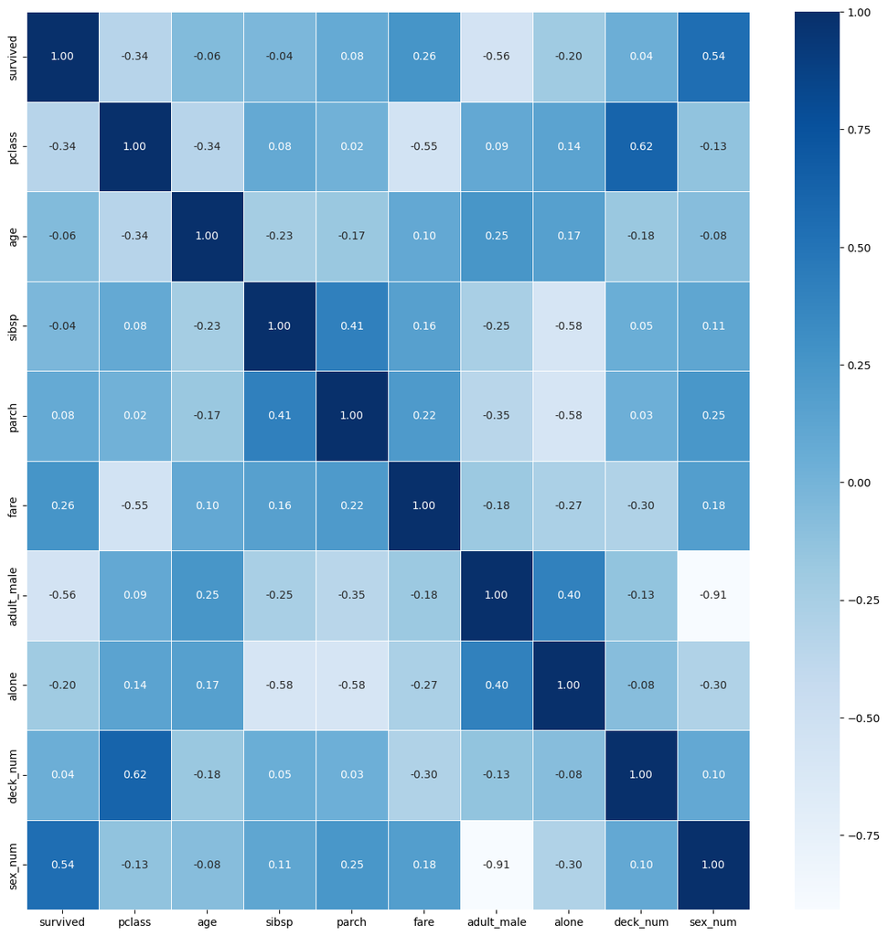

```python
import matplotlib.pyplot as plt
import seaborn as sns

plt.figure(figsize=(15,15))
sns.heatmap(data = titanic.corr(numeric_only=True), annot=True,
fmt = '.2f', linewidths=.5, cmap='Blues')
```

##### 상관관게가 있을까

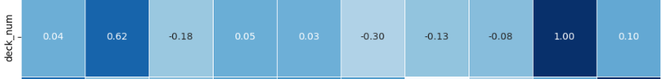

- pclass 는 손님이 1등석,2등석,3등석 컬럼인데 양의 상관관게가 있는것과 fare 컬럼에는 음의 상관관계가 있는것으로 볼때
- A로 갈수록 더 높은 비용을 내고 타이타닉호에 탑승을 했다는 정도는 유추가 가능해진다.
- 다만, 너무 비어있는 데이터가 많아서, 어떻게 처리할지는 후에 고민하는게 좋아보인다.

```python
# 결정 트리 사용을 하기 위해 데이터 생성
X = titanic[['age','pclass','sex_num']]
y = titanic['survived'].to_numpy()
```

```python
# 훈련 데이터셋과 테스트 데이터셋 분할
from sklearn.model_selection import train_test_split

X_train, X_test, y_train, y_test = train_test_split(
    X, y, test_size=0.3, random_state=42)
```

```python
X_train.shape, X_test.shape
```

```
((623, 3), (268, 3))
```

```python
# StandardScaler 객체 생성
from sklearn.preprocessing import StandardScaler

ss = StandardScaler()
ss.fit(X_train)

X_train_scaled = ss.transform(X_train)
X_test_scaled = ss.transform(X_test)
```

```python
# DecisionTreeClassifier 객체 생성
from sklearn.tree import DecisionTreeClassifier

dt = DecisionTreeClassifier(random_state=42)
dt.fit(X_train_scaled, y_train)

print(dt.score(X_train_scaled, y_train))
print(dt.score(X_test_scaled, y_test))
```

```
0.8796147672552167
0.7723880597014925
```

- 훈련 데이터셋과 테스트용 데이터셋의 차이가 너무너무크다
- 트리에 뎁스나, 최소 불순도의 지정이 필요한것으로 보인다.

```python
# depth 조절을 통한 스코어 비교
from sklearn.tree import DecisionTreeClassifier

dt = DecisionTreeClassifier(max_depth=5, random_state=42)

dt.fit(X_train_scaled, y_train)

print(dt.score(X_train_scaled, y_train))
print(dt.score(X_test_scaled, y_test))
```

```
0.8330658105939005
0.7611940298507462
```

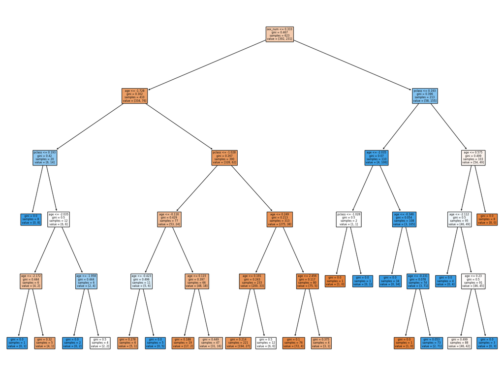

```python
import matplotlib.pyplot as plt
from sklearn.tree import plot_tree

plt.figure(figsize=(20, 15))
plot_tree(dt, filled=True, feature_names=['age','pclass','sex_num'])
plt.show()
```

- 아직은 과대적합으로 보이니 일단 불순도 조절도 해보도록 하자.

```python
# max_depth와 min_impurity_decrease 함께 적용
from sklearn.tree import DecisionTreeClassifier

dt = DecisionTreeClassifier(max_depth=5, min_impurity_decrease=0.005, random_state=42)
dt.fit(X_train_scaled, y_train)

print(dt.score(X_train_scaled, y_train))
print(dt.score(X_test_scaled, y_test))
```

```
0.8105939004815409
0.7985074626865671
```

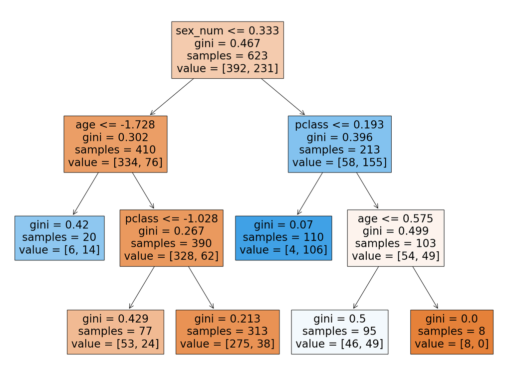

```python
import matplotlib.pyplot as plt
from sklearn.tree import plot_tree

plt.figure(figsize=(20,15))
plot_tree(dt, filled=True, feature_names=['age','pclass','sex_num'])
plt.show()
```

```python
from sklearn.tree import DecisionTreeClassifier

dt = DecisionTreeClassifier(max_depth=3, random_state=42)
dt.fit(X_train_scaled, y_train)

print(dt.score(X_train_scaled, y_train))
print(dt.score(X_test_scaled, y_test))
```

```
0.8105939004815409
0.8059701492537313
```

- 가장 괜찮은 데이터를 찾은거 같으니 이걸 사용하도록 하자.

```python
# 특성 중요도 출력
print(dt.feature_importances_)
```

```
[0.1220456  0.24656071 0.63139368]
```

- 남성(0), 여성(1)
- 생각보다 성별의 데이터 중요도가 높게 나오는걸 보니, 남성보다 여성의 생존률이 높았던것을 알 수 있다.
- 사고 당시에 남성들보다 여성들을 먼저 생존시키는 쪽으로 상황이 급박했음을 유추해볼 수 있다.

```python
# 특성 중요도를 모두 더하기(1이 되는 것 확인)
sum(dt.feature_importances_)
```

```
1.0
```

```python
age = int(input('추정되는 나이는? :'))
pclass = int(input('몇등석 탑승객? (1=1등석,2=2등석,3=3등석) :'))
sex = int(input('탑승객의 성별은? (0=Male,1=Female) :'))

data_set = [[age, pclass, sex]]
scaled = ss.transform(data_set)
predict = dt.predict(scaled)

print(f'이 승객의 생존 여부 : {predict[0]}')
```

```
추정되는 나이는? :38
몇등석 탑승객? (1=1등석,2=2등석,3=3등석) :1
탑승객의 성별은? (0=Male,1=Female) :1
이 승객의 생존 여부 : 1
```

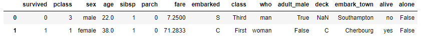

- 데이터의 대입해보니 잘 작동하는 것을 확인하였다.
- 이제 로지스트 회귀를 통해서 나이,승선가격,성별을 통해서 승객의 탑승등석을 알아보자.

```python
X = titanic[['age','fare','sex_num']]
y = titanic['class'].to_numpy()
```

```python
# 훈련 데이터셋과 테스트 데이터셋 분할
from sklearn.model_selection import train_test_split

X_train, X_test, y_train, y_test = train_test_split(
    X, y, test_size=0.3, random_state=42)
```

```python
# StandardScaler 객체 생성
from sklearn.preprocessing import StandardScaler

ss = StandardScaler()
ss.fit(X_train)

X_train_scaled = ss.transform(X_train)
X_test_scaled = ss.transform(X_test)
```

```python
# 로지스트 회귀 활용하기
from sklearn.linear_model import LogisticRegression

lr = LogisticRegression(C=20, max_iter=1000)
lr.fit(X_train_scaled, y_train)

print(lr.score(X_train_scaled, y_train))
print(lr.score(X_test_scaled, y_test))
```

```
0.7207062600321027
0.7164179104477612
```

- 확률은 낮지만, 과대적합도 아니고 과소적합도 아닌 적당한 데이터를 얻은 것 같다.

```python
# 분류 클래스 확인
print(lr.classes_)
```

```
['First' 'Second' 'Third']
```

```python
# 확률 확인하기
import numpy as np

proba = lr.predict_proba(X_test_scaled[:5])
print(lr.classes_)
print(np.round(proba, decimals=3))
```

```
['First' 'Second' 'Third']
[[0.043 0.233 0.724]
 [0.035 0.219 0.746]
 [0.011 0.156 0.833]
 [0.026 0.295 0.679]
 [0.006 0.193 0.801]]
```

```python
# 확률 1이 맞는지 확인해보기
0.043 + 0.233 + 0.724
```

```
1.0
```

```python
age = int(input('추정되는 나이는? :'))
fare = int(input('티켓의 가격은? :'))
sex = int(input('탑승객의 성별은? (0=Male,1=Female) :'))

data_set = [[age, fare, sex]]
scaled = ss.transform(data_set)
predict = lr.predict(scaled)

print(f'이 승객의 탑승 클래스 : {predict[0]}')
```

```
추정되는 나이는? :38
티켓의 가격은? :71
탑승객의 성별은? (0=Male,1=Female) :1
이 승객의 탑승 클래스 : First
```

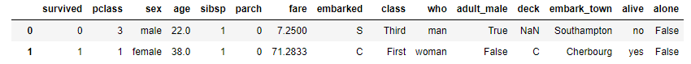

- 로지스티 회귀도 알맞은 값을 잘 찾아준다.